## In-class worksheet 11

**Feb 20, 2018**

In this worksheet, we will use the library tidyverse and ggthemes (for colorblind-friendly color scale `scale_color_colorblind()`):

```r
library(tidyverse)
theme_set(theme_bw(base_size=12)) # set default ggplot2 theme
# install.packages("ggthemes")
library(ggthemes)
```

# 1. Fitting a logistic regression model to the iris data set

We will work with the `iris` data set. Specifically, with a subset of the data that consists only of the species virginica and versicolor:

```r
# make a reduced iris data set that only contains virginica and versicolor species
iris.small <- filter(iris, Species %in% c("virginica", "versicolor"))
```

Fit a logistic regression model to the `iris.small` data set. Then successively remove predictors until only predictors with a p value less than 0.1 remain.

```r
# logistic regression
glm.out <- glm(Species ~ Sepal.Width + Sepal.Length + Petal.Width + Petal.Length,
               data = iris.small,
               family = binomial) # family = binomial required for logistic regression
summary(glm.out)
```

```
##
## Call:
## glm(formula = Species ~ Sepal.Width + Sepal.Length + Petal.Width +
##     Petal.Length, family = binomial, data = iris.small)
##
## Deviance Residuals:
##      Min        1Q    Median        3Q       Max
## -2.01105  -0.00541  -0.00001   0.00677   1.78065
##
## Coefficients:
##              Estimate Std. Error z value Pr(>|z|)
## (Intercept)   -42.638     25.707  -1.659   0.0972 .
## Sepal.Width    -6.681      4.480  -1.491   0.1359
## Sepal.Length   -2.465      2.394  -1.030   0.3032
## Petal.Width    18.286      9.743   1.877   0.0605 .
## Petal.Length    9.429      4.737   1.991   0.0465 *
## ---
## Signif. codes:  0 '***' 0.001 '**' 0.01 '*' 0.05 '.' 0.1 ' ' 1
##
## (Dispersion parameter for binomial family taken to be 1)
##
##     Null deviance: 138.629  on 99  degrees of freedom
## Residual deviance:  11.899  on 95  degrees of freedom
## AIC: 21.899
##
## Number of Fisher Scoring iterations: 10
```

We remove `Sepal.Length` as it has the highest P value:

```r
glm.out <- glm(Species ~ Sepal.Width + Petal.Width + Petal.Length,
               data = iris.small,
               family = binomial)
summary(glm.out)
```

```
##
## Call:
## glm(formula = Species ~ Sepal.Width + Petal.Width + Petal.Length,
##     family = binomial, data = iris.small)
##
## Deviance Residuals:
##      Min        1Q    Median        3Q       Max
## -1.75795  -0.00412   0.00000   0.00290   1.92193
##
## Coefficients:
##              Estimate Std. Error z value Pr(>|z|)
## (Intercept)   -50.527     23.995  -2.106   0.0352 *
## Sepal.Width    -8.376      4.761  -1.759   0.0785 .
## Petal.Width    21.430     10.707   2.001   0.0453 *
## Petal.Length    7.875      3.841   2.050   0.0403 *
## ---
## Signif. codes:  0 '***' 0.001 '**' 0.01 '*' 0.05 '.' 0.1 ' ' 1
##
## (Dispersion parameter for binomial family taken to be 1)
##
##     Null deviance: 138.629  on 99  degrees of freedom
## Residual deviance:  13.266  on 96  degrees of freedom
## AIC: 21.266
##
## Number of Fisher Scoring iterations: 10
```

Make a plot of the fitted probability as a function of the linear predictor, colored by species identity. Hint: you will have to make a new data frame combining data from the fitted model with data from the `iris.small` data frame.

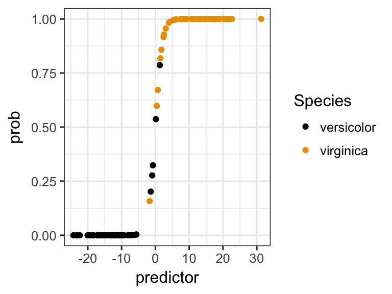

```r
lr_data <- data.frame(predictor=glm.out$linear.predictors, prob=glm.out$fitted.values, Species=iris.small$Species)
ggplot(lr_data, aes(x=predictor, y=prob, color=Species)) +
  geom_point() +
  scale_color_colorblind()
```

If we want to plot the original observations as “rug” along the bottom or top of the plot, we first need to make two separate data frames with the data points for either species, and then feed them individually into the `geom_rug()` function. In addition, we make a data frame that contains the logistic function, so we get a smooth black line underneath the points.

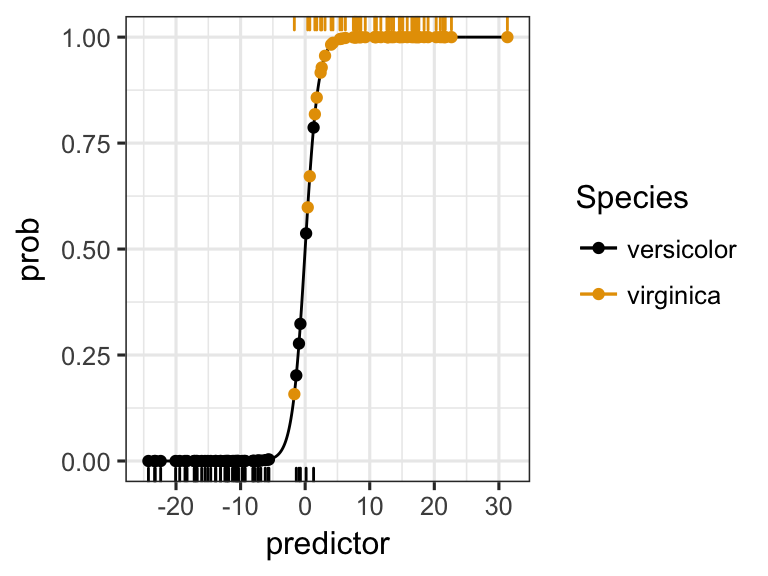

```r
# extract virginica and versicolor data
virg_data <- filter(lr_data, Species=="virginica")
vers_data <- filter(lr_data, Species=="versicolor")
# make data frame with logistic function
predictor <- (-250:320)/10
prob <- exp(predictor)/(1+exp(predictor))
log_fun_data <- data.frame(predictor, prob)
# plot
ggplot(lr_data, aes(x=predictor, y=prob, color=Species)) +
  geom_line(data=log_fun_data, color="black") +
  geom_point() +
  geom_rug(data=vers_data, sides='b') +
  geom_rug(data=virg_data, sides='t') +
  scale_color_colorblind()
```

Make a density plot that shows how the two species are separated by the linear predictor.

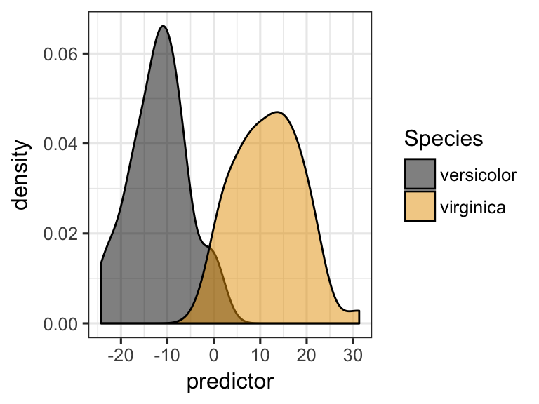

```r
ggplot(lr_data, aes(x=predictor, fill=Species)) +
  geom_density(alpha=.5) +
  scale_fill_colorblind()
```

# 2. Predicting the species

Assume you have obtained samples from three plants, with measurements as listed below. Predict the likelihood that each of these plants belongs to the species virginica.

```r
plant1 <- data.frame(Sepal.Length=6.4, Sepal.Width=2.8, Petal.Length=4.6, Petal.Width=1.8)
plant2 <- data.frame(Sepal.Length=6.3, Sepal.Width=2.5, Petal.Length=4.1, Petal.Width=1.7)
plant3 <- data.frame(Sepal.Length=6.7, Sepal.Width=3.3, Petal.Length=5.2, Petal.Width=2.3)
```

```r
predict(glm.out, plant1, type="response")
```

```
##         1
## 0.6934611
```

Plant 1 has a 69% probability of being virginica. It may be a virginica.

```r
predict(glm.out, plant2, type="response")
```

```
##          1
## 0.06002675
```

Plant 2 has a 6% probability of being virginica. It is very likely versicolor.

```r
predict(glm.out, plant3, type="response")
```

```
##         1
## 0.9999943
```

Plant 3 has a 99.999% probability of being virginica. It is very likely virginica.

# 3. If this was easy

Pick a cutoff predictor value at which you would decide that a specimen belongs to virginica rather than versicolor. Calculate how many virginicas you call correctly and how many incorrectly given that choice.

```r
cutoff <- 0
virg_true <- sum(lr_data$predictor > cutoff & lr_data$Species=="virginica")
virg_false <- sum(lr_data$predictor <= cutoff & lr_data$Species=="virginica")
virg_true
```

```
## [1] 49
```

```r
virg_false
```

```
## [1] 1
```

Now do the same calculation for versicolor.

```r
vers_true <- sum(lr_data$predictor <= cutoff & lr_data$Species=="versicolor")
vers_false <- sum(lr_data$predictor > cutoff & lr_data$Species=="versicolor")
vers_true
```

```
## [1] 48
```

```r
vers_false
```

```
## [1] 2
```

If we define a call of virginica as a positive and a call of versicolor as a negative, what are the true positive rate (sensitivity, true positives divided by all possible positives) and the true negative rate (specificity, true negatives divided by all possible negatives) in your analysis?

```r
tp <- virg_true/(virg_true + virg_false)
tn <- vers_true/(vers_true + vers_false)
tp
```

```
## [1] 0.98
```

```r
tn
```

```
## [1] 0.96
```

The true-positive rate (sensitivity) is 98%.

The true-negative rate (specificity) is 96%.